# Research Log. The COVID Economy: Political and economic analysis of the Pandemic in Colombia, Brazil, Argentina, and Chile

Nicolás Rubio García

March, 2023

Academic publication in the indexed FENADECO journal published in physical format at the National Congress of Economics Students (CNEE) in October 2023. Awaiting digital publication.

## Objective

The aim of this research was to assess the economic and political impact of the COVID-19 Pandemic on four Latin American countries: Colombia, Argentina, Brazil, and Chile. These countries were selected due to their prominence as the four largest economies and their substantial populations in the South American region.

The research employed a mixed-methods approach, incorporating both qualitative and quantitative methods. However, this document exclusively focuses on the quantitative aspect, utilizing linear regression models to estimate the GDP for the year 2020. This estimation assumes a hypothetical scenario in which the pandemic never occurred, allowing us to gauge the potential normal trajectory the economies might have followed. The data used in this analysis was sourced from the World Bank repository.

Additionally, the study includes a comparative analysis between the estimated GDP ($\hat{Y}$) and the actual GDP ($Y$). This comparison facilitates the calculation of the estimated impact of the pandemic, or the opportunity cost ($\Delta PIB_r$), represented by the formula:
$$\Delta PIB_r = |PIB_r - PIB_e|$$

## Country Dataframes

### Colombia

| Año | PIB | Inflación | Remesas | Desempleo | Población | Crecimiento |
| --- | --- | --- | --- | --- | --- | --- |
| 1980 | 33400735644 | 26.580645 | 0.3173583 | NA | 26900508 | 4.0873537 |
| 1981 | 36388366869 | 27.522936 | 0.4397010 | NA | 27496608 | 2.2768727 |
| 1982 | 38968039722 | 24.700240 | 0.2232599 | NA | 28101824 | 0.9484208 |
| 1983 | 38729822782 | 19.487179 | 0.1859033 | NA | 28714183 | 1.5739560 |
| 1984 | 38253120738 | 16.362661 | 0.2039049 | NA | 29331230 | 3.3506837 |
| 1985 | 34894411352 | 23.974182 | 0.3152367 | NA | 29951194 | 3.1071062 |
| 1986 | 34942489684 | 18.854593 | 1.1905276 | NA | 30572479 | 5.8240761 |
| 1987 | 36373307085 | 23.310388 | 1.7182930 | NA | 31195417 | 5.3689321 |
| 1988 | 39212550050 | 28.140066 | 1.1679934 | NA | 31822527 | 4.0641732 |
| 1989 | 39540080200 | 25.861386 | 1.1810801 | NA | 32457497 | 3.4140961 |

[output cut: 31 more lines]

### Argentina

| Año | PIB | Inflación | Remesas | Desempleo | Población | Crecimiento |
| --- | --- | --- | --- | --- | --- | --- |
| 1980 | 76961923742 | 100.8 | 0.072763254 | NA | 27896532 | 1.5187839 |
| 1981 | 78676842366 | 164.7 | 0.053382925 | NA | 28338514 | -5.1897891 |
| 1982 | 84307486837 | 343.3 | 0.033211760 | NA | 28794550 | -0.7356592 |
| 1983 | 103979106778 | 433.7 | 0.026928487 | NA | 29262049 | 4.3490933 |
| 1984 | 79092001998 | 688.0 | 0.040459211 | NA | 29737097 | 1.5707387 |
| 1985 | 88416668900 | 385.4 | 0.030537228 | NA | 30216284 | -5.1890244 |
| 1986 | 110934442763 | 81.9 | 0.028845865 | NA | 30698964 | 6.1533771 |
| 1987 | 111106191358 | 174.8 | 0.030601355 | NA | 31184411 | 2.7048688 |
| 1988 | 126206817196 | 387.7 | 0.023992365 | NA | 31668939 | -1.0899333 |
| 1989 | 76636898036 | 3079.5 | 0.034656934 | NA | 32148137 | -7.1569497 |

[output cut: 31 more lines]

### Brazil

| Año | PIB | Inflación | Remesas | Desempleo | Población | Crecimiento |
| --- | --- | --- | --- | --- | --- | --- |
| 1980 | 2.373935e+11 | 47.241650 | 0.04675781 | NA | 120694012 | 9.2000000 |
| 1981 | 2.580152e+11 | 32.133601 | 0.04805919 | NA | 123570327 | -4.2500000 |
| 1982 | 2.713141e+11 | 123.535719 | 0.02100886 | NA | 126498322 | 0.8300000 |
| 1983 | 1.896565e+11 | 275.586284 | 0.01529080 | NA | 129448815 | -2.9300000 |
| 1984 | 1.883400e+11 | 1281.349942 | 0.02442392 | NA | 132383569 | 5.4000000 |
| 1985 | 2.108798e+11 | 11749.639632 | 0.01896815 | NA | 135274083 | 7.8500000 |
| 1986 | 2.564809e+11 | 276.335968 | 0.01559571 | NA | 138108915 | 7.4900000 |
| 1987 | 2.830568e+11 | 14.578698 | 0.01483801 | NA | 140891606 | 3.5300000 |
| 1988 | 3.083336e+11 | 16.002091 | 0.01037837 | NA | 143627505 | -0.0600000 |
| 1989 | 3.470281e+11 | 15.173468 | 0.03457933 | NA | 146328305 | 3.1600000 |

[output cut: 31 more lines]

### Chile

| Año | PIB | Inflación | Remesas | Desempleo | Población | Crecimiento |
| --- | --- | --- | --- | --- | --- | --- |
| 1980 | 29036709872 | 35.1383405 | NA | NA | 11419350 | 7.9866208 |
| 1981 | 34509878044 | 19.6868327 | NA | NA | 11582020 | 6.5253704 |
| 1982 | 25325893206 | 9.9410269 | NA | NA | 11743909 | -11.0143051 |
| 1983 | 20355959237 | 27.2571947 | 0.0049125663 | NA | 11907955 | -5.0174205 |
| 1984 | 19622527480 | 19.8602057 | 0.0050961835 | NA | 12078137 | 4.1036832 |
| 1985 | 17702885394 | 30.7034989 | 0.0056487967 | NA | 12257238 | 4.0099162 |
| 1986 | 18891048819 | 19.4768379 | 0.0021174050 | NA | 12445833 | 5.3776923 |
| 1987 | 22255407685 | 19.8808457 | 0.0022466450 | NA | 12642917 | 6.4604685 |
| 1988 | 26040229793 | 14.6843513 | 0.0003840212 | NA | 12847712 | 7.3451105 |
| 1989 | 29885685143 | 17.0279367 | 0.0043499085 | NA | 13058758 | 9.9233829 |

[output cut: 31 more lines]

## Regression Models

### Colombia

```
##
## ================================================
##                         Dependent variable:
##                     ----------------------------
##                                 PIB
## ------------------------------------------------
## Crecimiento              2,710,386,848.000
##                         (5,364,606,186.000)
##
## Inflación                 203,176,021.000
##                         (3,553,649,502.000)
##
## Población                  19,681.310***
##                             (6,314.715)
##
## Desempleo                -7,342,711,911.000
##                         (5,398,795,191.000)
##
## Constant                -570,619,799,257.000
##                        (367,175,937,313.000)
##
## ------------------------------------------------
## Observations                     30
## R2                             0.854
## Adjusted R2                    0.831
## Residual Std. Error 46,528,199,772.000 (df = 25)
## F Statistic            36.580*** (df = 4; 25)
## ================================================
## Note:                *p<0.1; **p<0.05; ***p<0.01
```

### Argentina

```
##
## =================================================
##                          Dependent variable:
##                     -----------------------------
##                                  PIB
## -------------------------------------------------
## Crecimiento            -11,864,542,256.000***
##                          (3,702,561,927.000)
##
## Inflación                -1,495,864,480.000
##                          (1,232,443,896.000)
##
## Desempleo              -30,489,496,935.000***
##                          (6,181,145,279.000)
##
## Constant               734,980,059,626.000***
##                         (86,217,395,871.000)
##
## -------------------------------------------------
## Observations                     30
## R2                              0.527
## Adjusted R2                     0.472
## Residual Std. Error 110,056,336,315.000 (df = 26)
## F Statistic             9.651*** (df = 3; 26)
## =================================================
## Note:                 *p<0.1; **p<0.05; ***p<0.01
```

### Brazil

```
##
## =================================================
##                          Dependent variable:
##                     -----------------------------
##                                  PIB
## -------------------------------------------------
## Inflación                  -56,856,796.000
##                           (117,394,442.000)
##
## Población                   44,918.440***
##                              (3,681.263)
##
## Desempleo              -191,246,887,008.000***
##                         (30,082,849,003.000)
##
## Constant              -5,354,154,354,980.000***
##                         (624,163,248,117.000)
##
## -------------------------------------------------
## Observations                     30
## R2                              0.877
## Adjusted R2                     0.863
## Residual Std. Error 276,609,517,332.000 (df = 26)
## F Statistic            61.641*** (df = 3; 26)
## =================================================
## Note:                 *p<0.1; **p<0.05; ***p<0.01
```

### Chile

```
##
## ================================================
##                         Dependent variable:
##                     ----------------------------
##                                 PIB
## ------------------------------------------------
## Crecimiento              1,939,730,269.000
##                         (1,945,647,560.000)
##
## Inflación                 -123,436,187.000
##                         (1,532,146,819.000)
##
## Población                  57,499.830***
##                             (4,555.721)
##
## Desempleo              -10,372,526,919.000***
##                         (3,108,772,044.000)
##
## Constant              -707,046,840,947.000***
##                        (102,837,634,542.000)
##
## ------------------------------------------------
## Observations                     30
## R2                             0.953
## Adjusted R2                    0.946
## Residual Std. Error 21,028,878,500.000 (df = 25)
## F Statistic           127.923*** (df = 4; 25)
## ================================================
## Note:                *p<0.1; **p<0.05; ***p<0.01
```

## Assumptions Assestments

### Colombia

```
##
## The assumption tests have been completed and the results are available in a list. Enjoy it :)
```

```
## Las pruebas de supuestos han sido completadas y los resultados estan disponibles en una lista. Disfrutalo :)
```

```
## $Linearity
## [1] 6.519258e-08
##
## $Homoscedasticity
##
##  studentized Breusch-Pagan test
##
## data:  model
## BP = 9.1611, df = 4, p-value = 0.0572
##
##
## $Independence
##
##  Durbin-Watson test
##
## data:  model
## DW = 0.39975, p-value = 9.152e-11
## alternative hypothesis: true autocorrelation is not 0
##
##
## $Normality
##
##  Shapiro-Wilk normality test
##
## data:  model$residuals
## W = 0.95299, p-value = 0.2032
##
##
## $Multicollinearity
## Crecimiento   Inflación   Población   Desempleo
##    3.285065   11.898716   13.545704    4.033347
```

### Argentina

```
##
## The assumption tests have been completed and the results are available in a list. Enjoy it :)
```

```
## Las pruebas de supuestos han sido completadas y los resultados estan disponibles en una lista. Disfrutalo :)
```

```
## $Linearity
## [1] 8.65e-06
##
## $Homoscedasticity
##
##  studentized Breusch-Pagan test
##
## data:  model
## BP = 3.4386, df = 3, p-value = 0.3288
##
##
## $Independence
##
##  Durbin-Watson test
##
## data:  model
## DW = 0.80744, p-value = 3.644e-05
## alternative hypothesis: true autocorrelation is not 0
##
##
## $Normality
##
##  Shapiro-Wilk normality test
##
## data:  model$residuals
## W = 0.98103, p-value = 0.8521
##
##
## $Multicollinearity
## Crecimiento   Inflación   Desempleo
##    1.199294    1.351577    1.443867
```

### Brazil

```
##
## The assumption tests have been completed and the results are available in a list. Enjoy it :)
```

```
## Las pruebas de supuestos han sido completadas y los resultados estan disponibles en una lista. Disfrutalo :)
```

```
## $Linearity
## [1] 2.861023e-06
##
## $Homoscedasticity
##
##  studentized Breusch-Pagan test
##
## data:  model
## BP = 3.2021, df = 3, p-value = 0.3615
##
##
## $Independence
##
##  Durbin-Watson test
##
## data:  model
## DW = 0.64659, p-value = 6.144e-07
## alternative hypothesis: true autocorrelation is not 0
##
##
## $Normality
##
##  Shapiro-Wilk normality test
##
## data:  model$residuals
## W = 0.98324, p-value = 0.9036
##
##
## $Multicollinearity
## Inflación Población Desempleo
##  1.453979  1.764288  1.537182
```

### Chile

```
##
## The assumption tests have been completed and the results are available in a list. Enjoy it :)
```

```
## Las pruebas de supuestos han sido completadas y los resultados estan disponibles en una lista. Disfrutalo :)
```

```
## $Linearity
## [1] 5.575518e-08
##
## $Homoscedasticity
##
##  studentized Breusch-Pagan test
##
## data:  model
## BP = 5.1493, df = 4, p-value = 0.2723
##
##
## $Independence
##
##  Durbin-Watson test
##
## data:  model
## DW = 0.65477, p-value = 3.496e-07
## alternative hypothesis: true autocorrelation is not 0
##
##
## $Normality
##
##  Shapiro-Wilk normality test
##
## data:  model$residuals
## W = 0.96116, p-value = 0.3316
##
##
## $Multicollinearity
## Crecimiento   Inflación   Población   Desempleo
##    2.781089    3.386992    3.649597    2.701305
```

### Autocorrelation analysis

#### Addressing autocorrelation

##### Colombia

```
##
##  Durbin-Watson test
##
## data:  ColPIB2
## DW = 2.4555, p-value = 0.2037
## alternative hypothesis: true autocorrelation is not 0
```

##### Argentina

```
##
##  Durbin-Watson test
##
## data:  ArgPIB2
## DW = 1.9641, p-value = 0.9193
## alternative hypothesis: true autocorrelation is not 0
```

##### Brazil

```
##
##  Durbin-Watson test
##
## data:  BraPIB1
## DW = 1.5203, p-value = 0.09181
## alternative hypothesis: true autocorrelation is not 0
```

##### Chile

```
##
##  Durbin-Watson test
##
## data:  ChiPIB2
## DW = 1.6245, p-value = 0.4043
## alternative hypothesis: true autocorrelation is not 0
```

## Estimations of Impact

### Colombia

#### Comparative Visualizations

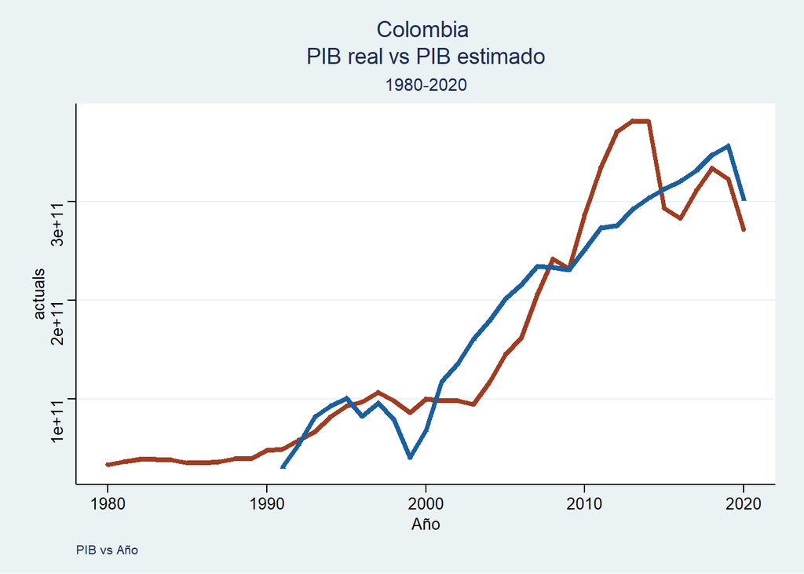

### Argentina

#### Analysis

The model for Argentina utilizes three predictor variables: annual GDP growth, inflation, and unemployment rate. These variables have negative coefficients, with the first and third being significant with $p-values < 0.01$. Therefore, as all three increase, GDP decreases. This can be interpreted as the combined effect of rising unemployment contracting economic activity and increasing inflation elevating prices, resulting in setbacks in GDP that could lead to economic decline. However, the intercept is positive, indicating that in the absence of the aforementioned effects, GDP will increase. Additionally, the coefficient of determination is $R^2 = 0.527$, meaning that the model parameters explain 52.7% of GDP behavior.

The result for the year 2020 is $PIB_e[Arg]$ = 26.83, which is compared to the actual GDP for 2020, $PIB_r[Arg]$ = 26.69. The comparison is as follows:
$$∆PIB_Arg = 0.14$$

This value represents a per capita GDP of $9,894.33, which is $1,315.31 higher than the actual value. This suggests a significant discrepancy between the estimated and actual GDP values and, consequently, a considerable margin of income loss for the population.

#### Comparative Visualizations

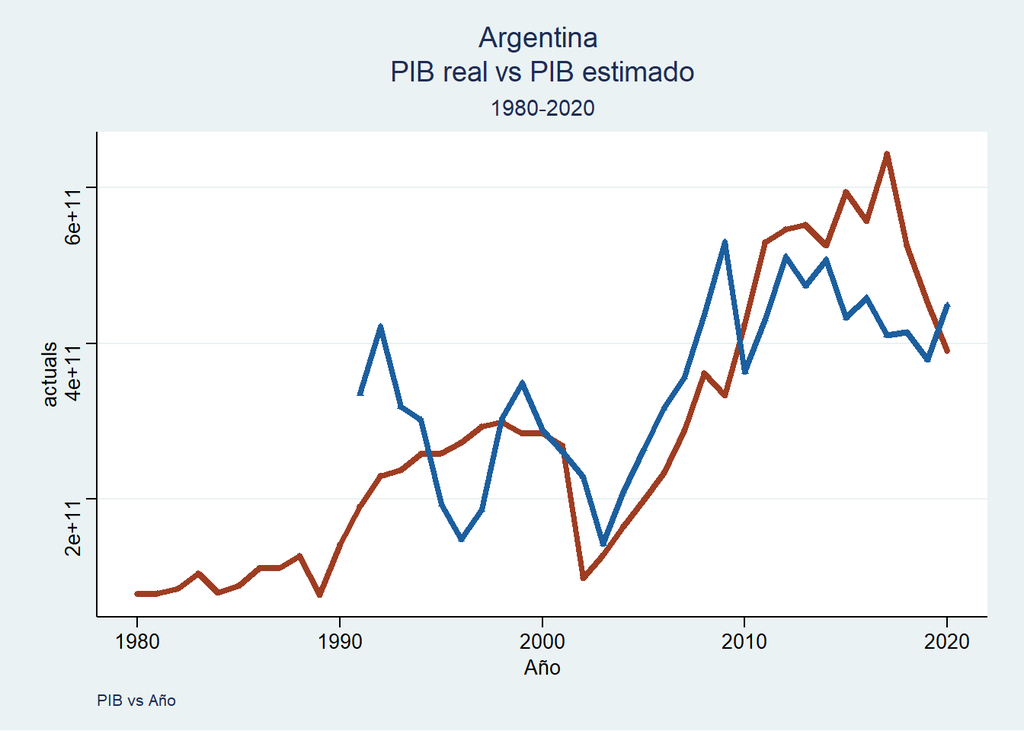

### Brazil

#### Analysis

In English:

For Brazil, three predictor variables were also used: inflation, population, and unemployment. The first and third variables have a negative $β_n$ coefficient, with the second and third being significant with $p-values < 0.01$. The analysis implies a similar effect to the case of Argentina, as once again, the combination of increasing unemployment and inflation generates a decrease that could lead to economic contraction. However, the intercept is negative, indicating that in the absence of the aforementioned effects, GDP will decrease. Furthermore, its coefficient of determination is 87.7%, indicating a high ability of the parameters to capture GDP behavior.

For the year 2020, the estimated GDP is $PIB_e[Bra]$ = 28.08, compared to the actual GDP for 2020, $PIB_r[Bra]$ = 27.9, resulting in a comparison of:
$$∆PIB_Bra = 0.18$$

This represents a per capita GDP of 7,411.25, which is $614.41 higher than the actual value, implying a potentially significant income loss for the population and, consequently, a reduction in levels of well-being and quality of life. Additionally, Brazil experienced one of the highest increases in debt as a percentage of GDP (22%), coupled with a 7.9 percentage point increase in the overall deficit.

#### Comparative Visualizations

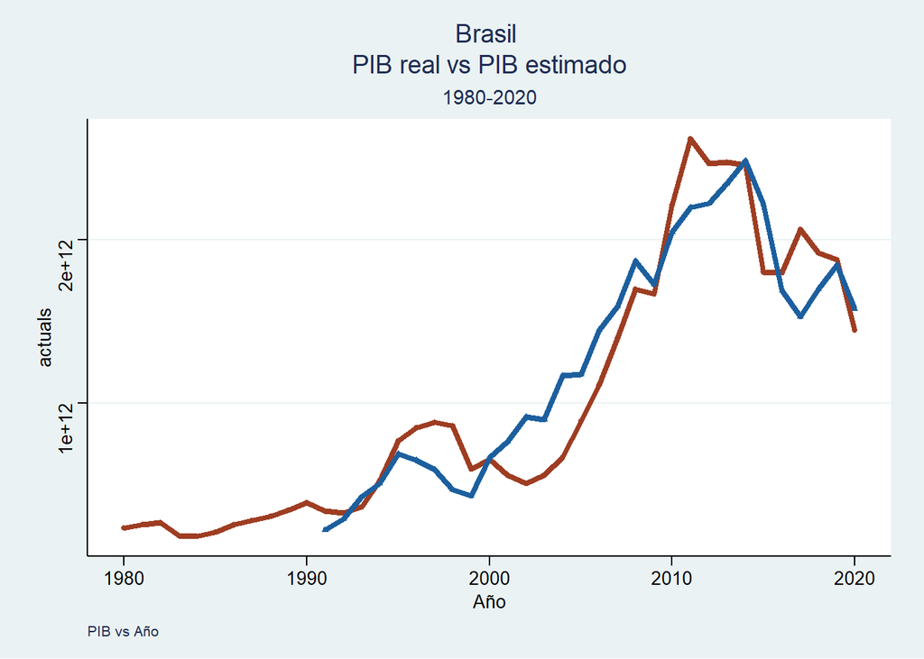

### Chile

#### Analysis

In the Chilean model, four predictor variables were used: annual GDP growth, inflation, population, and unemployment. The first and third variables have a positive coefficient, and likewise, the last two variables are significant with $p-values < 0.01$. In this case, there is a decreasing effect of inflation and unemployment compared to the last two models, but there is also a positive influence of growth and population. This could imply an increase in the production of goods and services, as well as their consumption, potentially preventing a decrease in GDP. However, the intercept is negative, indicating that in the absence of influences from the predictor variables, GDP could decrease. Similarly, the coefficient of determination, $R^2 = 0.953$, is the highest among the four models, allowing the conclusion that the parameters explain 95.3% of GDP behavior.

For the year 2020, the estimated GDP is P$IB_e[Chi]$ = 26.3, while the actual GDP for 2020 is $PIB_r[Chi]$ = 26.26. The comparison is as follows:
$$∆PIB_Chi =
0.04$$

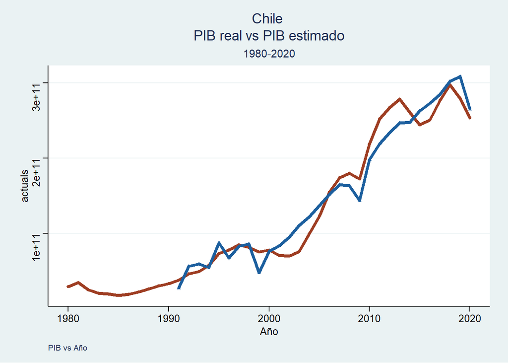